# Topic Modeling

text as data

NYT text analysis project

topic models

Text as Data Project: Headline Topic Modeling

Kristina Becvar https://kbec19.github.io/NYT-Analysis/ (UMass DACSS Program (My Academic Blog Link))https://kristinabecvar.com  
2022-04-28

# Prepare for Topic Modeling Analysis

```r
#no automatic data transformation
options(stringsAsFactors = F)
#supress math annotation
options("scipen" = 100, "digits" = 4)
#load packages
library(knitr)
library(kableExtra)
library(DT)
library(tm)
library(topicmodels)
library(reshape2)
library(ggplot2)
library(wordcloud)
library(pals)
library(SnowballC)
library(lda)
library(ldatuning)
library(flextable)
library(tidyverse)
```

I am using code from a wonderfully helpful tutorial to do some exploratory topic modeling with the headline data.

*Schweinberger, Martin. 2022. Topic Modeling with R. Brisbane: The University of Queensland. url: https://slcladal.github.io/topicmodels.html (Version 2022.03.18).*

## Create Corpus

Loading the entirety of the headlines pulled from the New York Times API, I will pre-process and create a corpus object.

I am transforming to lower case, removing English stopwords, removing punctuation, numbers, and stripping white space. I am going to use stemming, to begin the analysis, though I may go back and change this.

*Added on after running analyses in this post*

### Special Function

I had to create a function to remove ‘curly’ apostrophes after they showed up as top results in 2 models

```r
#creating functions using gsub to remove each of the curly apostrophes
exchanger1 <- function(x) gsub("’", "", x)
exchanger2 <- function(x) gsub("‘", "", x)

#corpus <- tm_map(corpus, exchanger1)
#corpus <- tm_map(corpus, exchanger2)
```

### Pre-Processing

```r
#load data
textdata <- read.csv("all_headlines.csv")
#load stop words
english_stopwords <- readLines("https://slcladal.github.io/resources/stopwords_en.txt", encoding = "UTF-8")
#create corpus object
corpus <- Corpus(DataframeSource(textdata))
#pre-processing chain
processedCorpus <- tm_map(corpus, content_transformer(tolower))
processedCorpus <- tm_map(processedCorpus, removeWords, english_stopwords)
processedCorpus <- tm_map(processedCorpus, removePunctuation, preserve_intra_word_dashes = TRUE)
processedCorpus <- tm_map(processedCorpus, removeNumbers)
processedCorpus <- tm_map(processedCorpus, stripWhitespace)
processedCorpus <- tm_map(processedCorpus, exchanger1)
processedCorpus <- tm_map(processedCorpus, exchanger2)
```

## Create Document Term Matrix

The “topicmodels” package requires a Document Term Matrix.

```r
minimumFrequency <- 1
DTM <- DocumentTermMatrix(processedCorpus, control = list(bounds = list(global = c(minimumFrequency, Inf))))
#preview
dim(DTM)
```

```
[1] 1872 3422
```

I need to clean up the matrix to remove empty rows due to the vocabulary being stemmed/stop words being removed.

```r
sel_idx <- slam::row_sums(DTM) > 0
DTM <- DTM[sel_idx, ]
textdata <- textdata[sel_idx, ]
```

## Sample Headlines

Choose 5 random numbers to pull and use as examples when examining models.

```r
exampleIds <- c(180, 250, 330, 430, 510)
lapply(corpus[exampleIds], as.character)
```

```
$`180`
[1] "Afghanistan to Release Last Taliban Prisoners, Removing Final Hurdle to Talks"

$`250`
[1] "Trump’s Campaign Talk of Troop Withdrawals Doesn’t Match Military Reality"

$`330`
[1] "U.S. Leaves Behind Afghan Bases — and a Legacy of Land Disputes"

$`430`
[1] "Blinken, Without Leaving Home, Tries to Mend Fences With Allies Abroad"

$`510`
[1] "War, Peace and Taliban Spreadsheets"
```

# Gibbs Method

Now I can create models to examine the metrics that can lead to choosing the optical number of topics. Since I am unsure about whether the VEM or Gibbs method will be most appropriate I’m going to try both.

## Determine K

```r
#create models with different number of topics
result <- ldatuning::FindTopicsNumber(
  DTM,
  topics = seq(from = 2, to = 20, by = 1),
  metrics = c("CaoJuan2009",  "Deveaud2014", "Arun2010", "Griffiths2004"),
  method = "Gibbs",
  control = list(seed = 11),
  verbose = TRUE
)
```

```
fit models... done.
calculate metrics:
  CaoJuan2009... done.
  Deveaud2014... done.
  Arun2010... done.
  Griffiths2004... done.
```

## Choose K

After inspecting the results of all four metrics from the “ldatuning” package relevant to the Gibbs method, it seems that a good starting point will be 5 topics, or “K”.

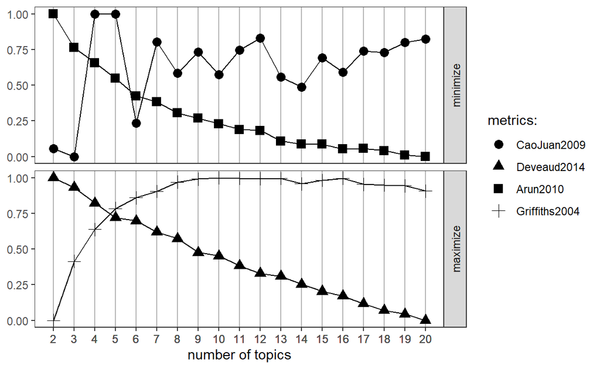

```r
FindTopicsNumber_plot(result)
```

## Compute Model at K(5)

I’ll set the topic model to run 1,000 iterations

```r
#number of topics
K <- 5
#set random number generator seed
set.seed(123)
#compute the LDA model, inference via 1000 iterations of Gibbs sampling
topicModel <- LDA(DTM, K, method="Gibbs", control=list(iter = 1000, verbose = 25, alpha = 1.0))
```

[output not shown]

### Model Details

```r
#look at posterior distributions
tmResult <- posterior(topicModel)
#format of the resulting object
attributes(tmResult)
```

```
$names
[1] "terms"  "topics"
```

```r
#lengthOfVocab
nTerms(DTM)
```

```
[1] 3422
```

```r
#topics are probability distributions over the entire vocabulary
#get beta from results
beta <- tmResult$terms
#K distributions over nTerms(DTM) terms
dim(beta)
```

```
[1]    5 3422
```

```r
#rows in beta sum to 1
rowSums(beta)
```

```
1 2 3 4 5
1 1 1 1 1
```

```r
#size of collection
nDocs(DTM)
```

```
[1] 1872
```

```r
#for every document we have a probability distribution of its contained topics
theta <- tmResult$topics
#nDocs(DTM) distributions over K topics
dim(theta)
```

```
[1] 1872    5
```

```r
#rows in theta sum to 1
rowSums(theta)[1:10]
```

```
 1  2  3  4  5  6  7  8  9 10
 1  1  1  1  1  1  1  1  1  1
```

### Model Preview

Now I can look at the 10 most likely terms within the probabilities of the inferred topics. I’ll take a look at them for each of the 5 topics to get a clearer idea of how the topics are represented in this model.

```r
terms(topicModel, 10)
```

```
      Topic 1        Topic 2    Topic 3       Topic 4
 [1,] "trump"        "biden"    "taliban"     "afghanistan"
 [2,] "military"     "china"    "afghan"      "war"
 [3,] "house"        "world"    "afghans"     "afghan"
 [4,] "democrats"    "migrants" "peace"       "biden"
 [5,] "bounties"     "home"     "women"       "kabul"
 [6,] "russia"       "refugees" "afghanistan" "exit"
 [7,] "russian"      "allies"   "talks"       "withdrawal"
 [8,] "top"          "takes"    "kabul"       "troops"
 [9,] "general"      "pandemic" "forces"      "end"
[10,] "intelligence" "faces"    "deal"        "veterans"
      Topic 5
 [1,] "pentagon"
 [2,] "leader"
 [3,] "pakistan"
 [4,] "president"
 [5,] "killed"
 [6,] "troops"
 [7,] "iran"
 [8,] "attack"
 [9,] "guant<e1>namo"
[10,] "defense"
```

### Visualization of Topic Distributions

To look at the models more easily, I’ll name the strings with the top 5 most likely terms for each topic.

```r
top5termsPerTopic <- terms(topicModel, 5)
topicNames <- apply(top5termsPerTopic, 2, paste, collapse=" ")
```

After looking into the documents, I can visualize the topic distributions within the documents.

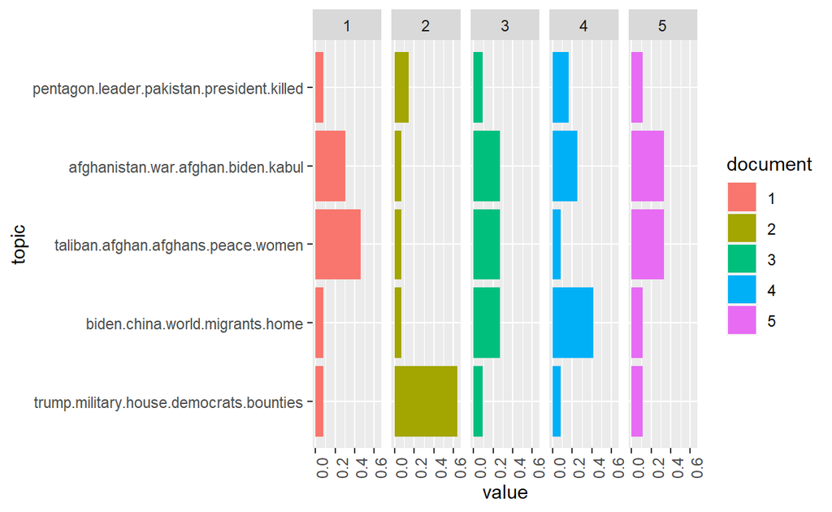

```r
N <- length(exampleIds)
# get topic proportions form example documents
topicProportionExamples <- theta[exampleIds,]
colnames(topicProportionExamples) <- topicNames
vizDataFrame <- melt(cbind(data.frame(topicProportionExamples), document = factor(1:N)), variable.name = "topic", id.vars = "document")
ggplot(data = vizDataFrame, aes(topic, value, fill = document), ylab = "proportion") +
  geom_bar(stat="identity") +
  theme(axis.text.x = element_text(angle = 90, hjust = 1)) +
  coord_flip() +
  facet_wrap(~ document, ncol = N)
```

### Topic Ranking

I will try to get a more meaningful order of top terms per topic by re-ranking them with a specific score (Chang et al. 2009).

The idea of re-ranking terms is similar to the idea of TF-IDF. The more a term appears in top levels with regard to its probability, the less meaningful it is to describe the topic. Hence, the scoring advanced favors terms to describe a topic.

```r
# re-rank top topic terms for topic names
topicNames <- apply(lda::top.topic.words(beta, 5, by.score = T), 2, paste, collapse = " ")
```

#### Approach 1

Sort topics according to their probability within the entire collection:

```r
#mean probablities over all paragraphs
topicProportions <- colSums(theta) / nDocs(DTM)
#assign the topic names we created before
names(topicProportions) <- topicNames
#show summed proportions in decreased order
sort(topicProportions, decreasing = TRUE)
```

```
     taliban afghan afghans peace women
                                 0.2084
      afghanistan war afghan kabul exit
                                 0.2043
   pentagon leader pakistan killed iran
                                 0.1981
trump military house democrats bounties
                                 0.1961
    biden china world refugees migrants
                                 0.1932
```

#### Approach 2

We count how often a topic appears as a primary topic within a paragraph This method is also called Rank-1.

```r
countsOfPrimaryTopics <- rep(0, K)
names(countsOfPrimaryTopics) <- topicNames
for (i in 1:nDocs(DTM)) {
  topicsPerDoc <- theta[i, ] # select topic distribution for document i
  # get first element position from ordered list
  primaryTopic <- order(topicsPerDoc, decreasing = TRUE)[1]
  countsOfPrimaryTopics[primaryTopic] <- countsOfPrimaryTopics[primaryTopic] + 1
}
sort(countsOfPrimaryTopics, decreasing = TRUE)
```

```
     taliban afghan afghans peace women
                                    431
trump military house democrats bounties
                                    412
    biden china world refugees migrants
                                    380
      afghanistan war afghan kabul exit
                                    349
   pentagon leader pakistan killed iran
                                    300
```

Sorting topics by the Rank-1 method places topics with rather specific thematic coherences in upper ranks of the list.

### Wordcloud of Topic

The wordcloud is a good preliminary way to look at the topics. I’ll choose topic “3”, because across the five sample documents, topic “3” seems to be the most broad capture of the headline topic prevalence over the time period in the modeling. It is also intuitively not an unreasonable choice.

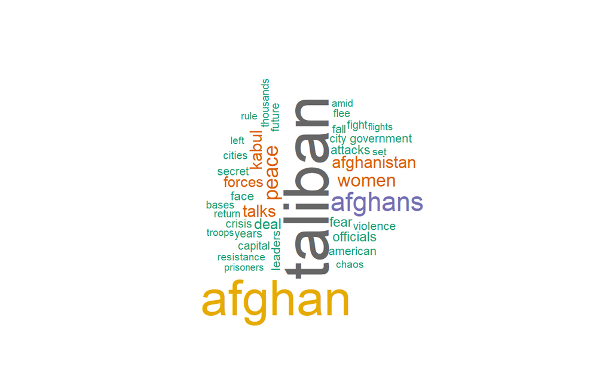

```r
# visualize topics as word cloud
topicToViz <- 3 # change for your own topic of interest
#topicToViz <- grep('fear', topicNames)[1] # Or select a topic by a term contained in its name
# select to 40 most probable terms from the topic by sorting the term-topic-probability vector in decreasing order
top40terms <- sort(tmResult$terms[topicToViz,], decreasing=TRUE)[1:40]
words <- names(top40terms)
# extract the probabilites of each of the 40 terms
probabilities <- sort(tmResult$terms[topicToViz,], decreasing=TRUE)[1:40]
# visualize the terms as wordcloud
mycolors <- brewer.pal(8, "Dark2")
wordcloud(words, probabilities, random.order = FALSE, color = mycolors)
```

## Topic Distribution Adjustment

Changing the alpha to a lower level

For alpha values greater than one, the samples start to congregate in the center of the triangle. This means that as alpha gets bigger, your samples will more likely be uniform — that is, represent an even mixture of all the topics. Since that was definitely the case in the first sample, I will lower it from 1.0 to 0.1.

```r
#see alpha from previous model
attr(topicModel, "alpha")
```

```
[1] 1
```

```r
#prior alpha was 1.0

topicModelb <- LDA(DTM, K, method="Gibbs", control=list(iter = 1000, verbose = 25, alpha = 0.1))
```

[output not shown]

### Model Details

```r
#look at posterior distributions
tmResultb <- posterior(topicModelb)
#format of the resulting object
attributes(tmResultb)
```

```
$names
[1] "terms"  "topics"
```

```r
#topics are probability distributions over the entire vocabulary
#get beta from results
betab <- tmResultb$terms
#K distributions over nTerms(DTM) terms
dim(betab)
```

```
[1]    5 3422
```

```r
#rows in beta sum to 1
rowSums(betab)
```

```
1 2 3 4 5
1 1 1 1 1
```

```r
#for every document we have a probability distribution of its contained topics
thetab <- tmResultb$topics
#nDocs(DTM) distributions over K topics
dim(thetab)
```

```
[1] 1872    5
```

```r
#rows in theta sum to 1
rowSums(thetab)[1:10]
```

```
 1  2  3  4  5  6  7  8  9 10
 1  1  1  1  1  1  1  1  1  1
```

### Model Preview

```r
terms(topicModelb, 10)
```

```
      Topic 1     Topic 2       Topic 3       Topic 4
 [1,] "trump"     "troops"      "biden"       "afghanistan"
 [2,] "biden"     "afghanistan" "war"         "biden"
 [3,] "military"  "afghan"      "afghanistan" "trump"
 [4,] "house"     "military"    "afghan"      "world"
 [5,] "iran"      "pentagon"    "exit"        "afghan"
 [6,] "president" "trump"       "veterans"    "aid"
 [7,] "democrats" "kabul"       "migrants"    "power"
 [8,] "russia"    "war"         "end"         "policy"
 [9,] "russian"   "years"       "withdrawal"  "india"
[10,] "bounties"  "drone"       "faces"       "takes"
      Topic 5
 [1,] "taliban"
 [2,] "afghan"
 [3,] "afghanistan"
 [4,] "kabul"
 [5,] "peace"
 [6,] "afghans"
 [7,] "women"
 [8,] "talks"
 [9,] "deal"
[10,] "attack"
```

### Visualization of New Distribution Alpha

```r
tmResultb <- posterior(topicModelb)
thetab <- tmResultb$topics
betab <- tmResultb$terms
#reset topicnames
topicNamesb <- apply(terms(topicModelb, 5), 2, paste, collapse = " ")
```

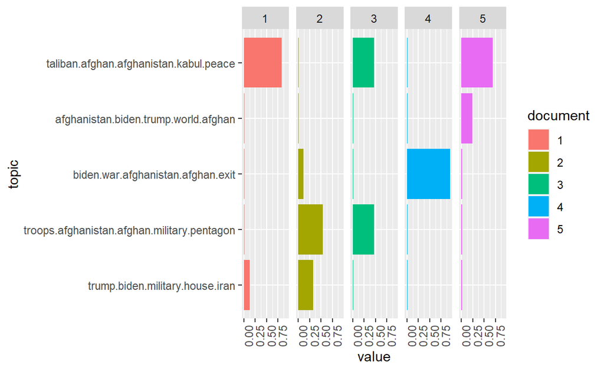

```r
# get topic proportions form example documents
topicProportionExamplesb <- thetab[exampleIds,]
colnames(topicProportionExamplesb) <- topicNamesb
vizDataFrameb <- melt(cbind(data.frame(topicProportionExamplesb), document = factor(1:N)), variable.name = "topic", id.vars = "document")
ggplot(data = vizDataFrameb, aes(topic, value, fill = document), ylab = "proportion") +
  geom_bar(stat="identity") +
  theme(axis.text.x = element_text(angle = 90, hjust = 1)) +
  coord_flip() +
  facet_wrap(~ document, ncol = N)
```

### Topic Ranking

I will try to get a more meaningful order of top terms per topic by re-ranking them with a specific score (Chang et al. 2009).

The idea of re-ranking terms is similar to the idea of TF-IDF. The more a term appears in top levels with regard to its probability, the less meaningful it is to describe the topic. Hence, the scoring advanced favors terms to describe a topic.

```r
# re-rank top topic terms for topic names
topicNamesb <- apply(lda::top.topic.words(betab, 5, by.score = T), 2, paste, collapse = " ")
```

#### Approach 1

Sort topics according to their probability within the entire collection:

```r
#mean probablities over all paragraphs
topicProportionsb <- colSums(thetab) / nDocs(DTM)
#assign the topic names we created before
names(topicProportionsb) <- topicNamesb
#show summed proportions in decreased order
sort(topicProportionsb, decreasing = TRUE)
```

```
taliban afghan peace kabul afghanistan
                                0.2432
   biden war veterans afghanistan exit
                                0.1992
  military pentagon troops kabul drone
                                0.1990
       trump house military biden iran
                                0.1807
          world biden trump policy aid
                                0.1779
```

#### Approach 2

We count how often a topic appears as a primary topic within a paragraph This method is also called Rank-1.

```r
countsOfPrimaryTopicsb <- rep(0, K)
names(countsOfPrimaryTopicsb) <- topicNamesb
for (i in 1:nDocs(DTM)) {
  topicsPerDocb <- thetab[i, ] # select topic distribution for document i
  # get first element position from ordered list
  primaryTopicb <- order(topicsPerDocb, decreasing = TRUE)[1]
  countsOfPrimaryTopicsb[primaryTopicb] <- countsOfPrimaryTopicsb[primaryTopicb] + 1
}
sort(countsOfPrimaryTopicsb, decreasing = TRUE)
```

```
taliban afghan peace kabul afghanistan
                                   455
  military pentagon troops kabul drone
                                   388
   biden war veterans afghanistan exit
                                   367
       trump house military biden iran
                                   346
          world biden trump policy aid
                                   316
```

Sorting topics by the Rank-1 method places topics with rather specific thematic coherences in upper ranks of the list.

### Wordcloud of New Topic Model

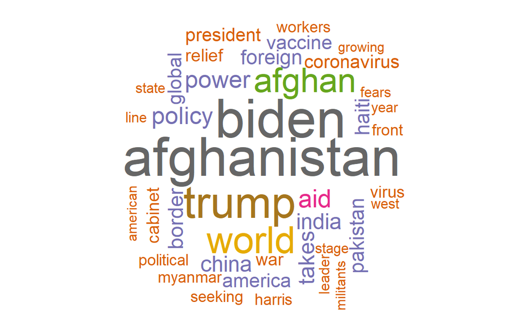

```r
# visualize topics as word cloud
topicToVizb <- 4 # change for your own topic of interest
#topicToViz <- grep('fear', topicNames)[1] # Or select a topic by a term contained in its name
# select to 40 most probable terms from the topic by sorting the term-topic-probability vector in decreasing order
top40termsb <- sort(tmResultb$terms[topicToVizb,], decreasing=TRUE)[1:40]
wordsb <- names(top40termsb)
# extract the probabilites of each of the 40 terms
probabilitiesb <- sort(tmResultb$terms[topicToVizb,], decreasing=TRUE)[1:40]
# visualize the terms as wordcloud
mycolors <- brewer.pal(8, "Dark2")
wordcloud(wordsb, probabilitiesb, random.order = FALSE, color = mycolors)
```

## Filtering Documents by “Withdrawal”

The fact that a topic model conveys of topic probabilities for each document, resp. paragraph in our case, makes it possible to use it for thematic filtering of a collection. AS filter we select only those documents which exceed a certain threshold of their probability value for certain topics (for example, each document which contains topic 4 to more than 20 percent).

```r
topicToFilterb <- 4  # you can set this manually ...
# ... or have it selected by a term in the topic name (e.g. 'children')
#topicToFilterb <- grep('withdrawal', topicNamesb)[1]
topicThresholdb <- 0.2
selectedDocumentIndexesb <- which(thetab[, topicToFilterb] >= topicThresholdb)
filteredCorpusb <- corpus[selectedDocumentIndexesb]
# show length of filtered corpus
filteredCorpusb
```

```
<<SimpleCorpus>>
Metadata:  corpus specific: 1, document level (indexed): 2
Content:  documents: 468
```

### Visualizing Topic Proportions Over Time

In a last step, we provide a distant view on the topics in the data over time. For this, we aggregate mean topic proportions per month for all of the topics. These aggregated topic proportions can then be visualized, e.g. as a bar plot.

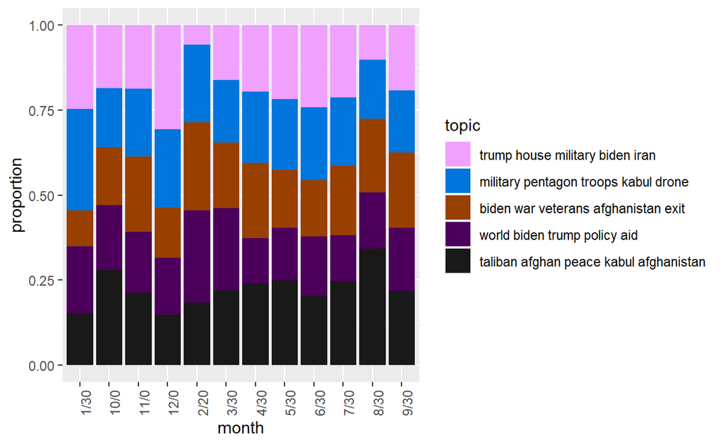

```r
#convert non-graph characters to combat error in grid.Call
topicNamesb=str_replace_all(topicNamesb,"[^[:graph:]]", " ")
# append month information for aggregation
textdata$month <- paste0(substr(textdata$month.ended, 0, 3), "0")
# get mean topic proportions per month
topic_proportion_per_month <- aggregate(thetab, by = list(month = textdata$month), mean)
# set topic names to aggregated columns
colnames(topic_proportion_per_month)[2:(K+1)] <- topicNamesb
# reshape data frame
vizDataFrame <- melt(topic_proportion_per_month, id.vars = "month")
# plot topic proportions per month as bar plot
ggplot(vizDataFrame, aes(x=month, y=value, fill=variable)) +
  geom_bar(stat = "identity") + ylab("proportion") +
  scale_fill_manual(values = paste0(alphabet(20), "FF"), name = "topic") +
  theme(axis.text.x = element_text(angle = 90, hjust = 1))
```

# VEM Method

## Determine K

The VEM method gives 3 metrics; the “Griffiths2004” metric is not compatible with this method.

```r
#create models with different number of topics
result2 <- ldatuning::FindTopicsNumber(
  DTM,
  topics = seq(from = 2, to = 20, by = 1),
  metrics = c("CaoJuan2009",  "Deveaud2014", "Arun2010", "Griffiths2004"),
  method = "VEM",
  control = list(seed = 11),
  verbose = TRUE
)
```

```
'Griffiths2004' is incompatible with 'VEM' method, excluded.
fit models... done.
calculate metrics:
  CaoJuan2009... done.
  Deveaud2014... done.
  Arun2010... done.
```

## Choose K

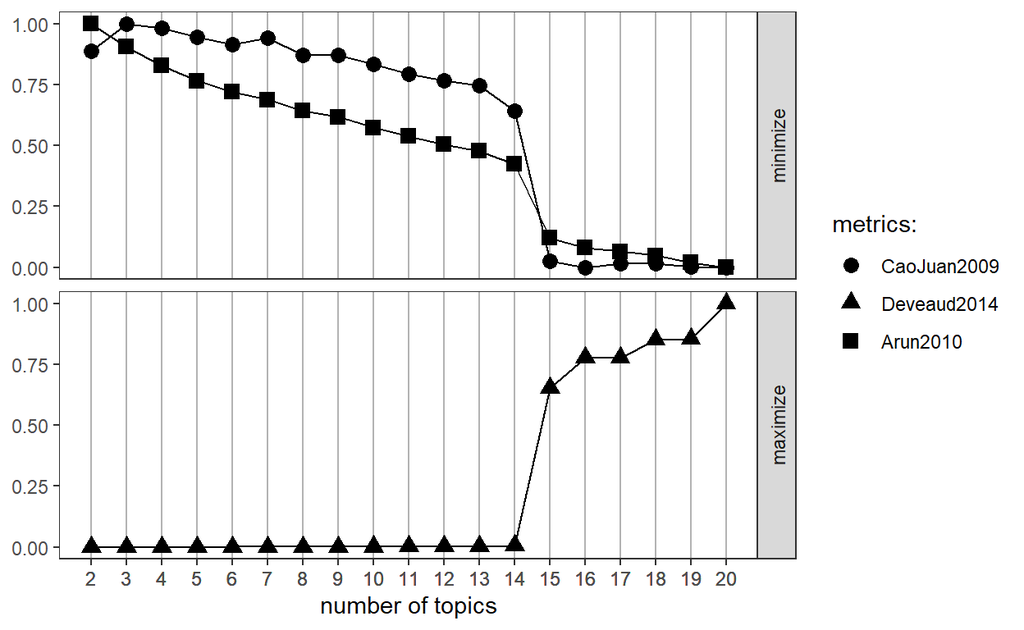

```r
FindTopicsNumber_plot(result2)
```

## Compute Model at K(3)

Using the VEM model, the alpha is automatically generated

```r
#number of topics
K2 <- 3
#set random number generator seed
set.seed(11)
#compute the LDA model via VEM method
topicModel2 <- LDA(DTM, K2, method="VEM", control=list(alpha = 1.0))
```

### Model Details

```r
#look at posterior distributions
tmResult2 <- posterior(topicModel2)
#format of the resulting object
attributes(tmResult2)
```

```
$names
[1] "terms"  "topics"
```

```r
#topics are probability distributions over the entire vocabulary
#get beta from results
beta2 <- tmResult2$terms
#K distributions over nTerms(DTM) terms
dim(beta2)
```

```
[1]    3 3422
```

```r
#rows in beta sum to 1
rowSums(beta2)
```

```
1 2 3
1 1 1
```

```r
#for every document we have a probability distribution of its contained topics
theta2 <- tmResult2$topics
#nDocs(DTM) distributions over K topics
dim(theta2)
```

```
[1] 1872    3
```

```r
#rows in theta sum to 1
rowSums(theta2)[1:10]
```

```
 1  2  3  4  5  6  7  8  9 10
 1  1  1  1  1  1  1  1  1  1
```

### Model Preview

```r
terms(topicModel2, 10)
```

```
      Topic 1       Topic 2     Topic 3
 [1,] "afghan"      "taliban"   "afghanistan"
 [2,] "taliban"     "afghans"   "trump"
 [3,] "afghanistan" "biden"     "war"
 [4,] "biden"       "afghan"    "biden"
 [5,] "peace"       "china"     "troops"
 [6,] "leader"      "trump"     "afghan"
 [7,] "talks"       "kabul"     "military"
 [8,] "women"       "democrats" "kabul"
 [9,] "forces"      "war"       "exit"
[10,] "attack"      "veterans"  "end"
```

### Visualization of Topic Distributions

To look at the models more easily, I’ll name the strings with the top 5 most likely terms for each topic.

```r
top5termsPerTopic2 <- terms(topicModel2, 5)
topicNames2 <- apply(top5termsPerTopic2, 2, paste, collapse=" ")
Encoding(topicNames2) <- "UTF-8"
```

After looking into the documents, I can visualize the topic distributions within the documents.

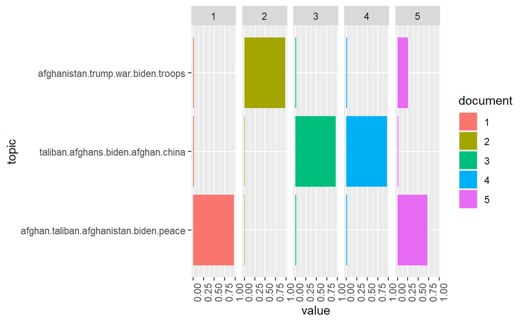

```r
N <- length(exampleIds)
# get topic proportions form example documents
topicProportionExamples2 <- theta2[exampleIds,]
colnames(topicProportionExamples2) <- topicNames2
vizDataFrame2 <- melt(cbind(data.frame(topicProportionExamples2), document = factor(1:N)), variable.name = "topic", id.vars = "document")
ggplot(data = vizDataFrame2, aes(topic, value, fill = document), ylab = "proportion") +
  geom_bar(stat="identity") +
  theme(axis.text.x = element_text(angle = 90, hjust = 1)) +
  coord_flip() +
  facet_wrap(~ document, ncol = N)
```

### Topic Ranking

I will try to get a more meaningful order of top terms per topic by re-ranking them with a specific score (Chang et al. 2009).

The idea of re-ranking terms is similar to the idea of TF-IDF. The more a term appears in top levels with regard to its probability, the less meaningful it is to describe the topic. Hence, the scoring advanced favors terms to describe a topic.

```r
# re-rank top topic terms for topic names
topicNames2 <- apply(lda::top.topic.words(beta2, 5, by.score = T), 2, paste, collapse = " ")
```

#### Approach 1

Sort topics according to their probability within the entire collection:

```r
#mean probablities over all paragraphs
topicProportions2 <- colSums(theta2) / nDocs(DTM)
#assign the topic names we created before
names(topicProportions2) <- topicNames2
#show summed proportions in decreased order
sort(topicProportions2, decreasing = TRUE)
```

```
  taliban peace leader talks afghanistan
                                  0.3411
       afghanistan troops trump war exit
                                  0.3409
afghans taliban china migrants democrats
                                  0.3180
```

#### Approach 2

We count how often a topic appears as a primary topic within a paragraph This method is also called Rank-1.

```r
countsOfPrimaryTopics2 <- rep(0, K2)
names(countsOfPrimaryTopics2) <- topicNames2
for (i in 1:nDocs(DTM)) {
  topicsPerDoc2 <- theta2[i, ] # select topic distribution for document i
  # get first element position from ordered list
  primaryTopic2 <- order(topicsPerDoc2, decreasing = TRUE)[1]
  countsOfPrimaryTopics2[primaryTopic2] <- countsOfPrimaryTopics2[primaryTopic2] + 1
}
sort(countsOfPrimaryTopics2, decreasing = TRUE)
```

```
  taliban peace leader talks afghanistan
                                     646
       afghanistan troops trump war exit
                                     636
afghans taliban china migrants democrats
                                     590
```

Sorting topics by the Rank-1 method places topics with rather specific thematic coherences in upper ranks of the list.

### Wordcloud of Topic

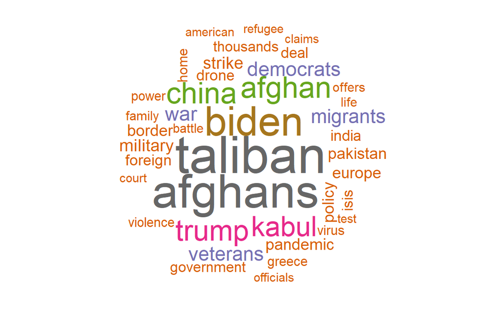

```r
#visualize topics as word cloud
topicToViz2 <- 2 # change for your own topic of interest
#topicToViz <- grep('fear', topicNames)[1] # Or select a topic by a term contained in its name
#select to 40 most probable terms from the topic by sorting the term-topic-probability vector in decreasing order
top40terms2 <- sort(tmResult2$terms[topicToViz2,], decreasing=TRUE)[1:40]
words2 <- names(top40terms2)
#convert non-graph characters to combat error in wordcloud
words2=str_replace_all(words2,"[^[:graph:]]", " ")
#extract the probabilites of each of the 40 terms
probabilities2 <- sort(tmResult2$terms[topicToViz2,], decreasing=TRUE)[1:40]
#visualize the terms as wordcloud
mycolors <- brewer.pal(8, "Dark2")
wordcloud(words2, probabilities2, random.order = FALSE, color = mycolors)
```

## Topic Distribution Adjustment

```r
# see alpha from previous model
attr(topicModel2, "alpha")
```

```
[1] 0.119
```

```r
topicModel2b <- LDA(DTM, K2, method="VEM", control=list(alpha = 0.03))
```

### Model Details

```r
#look at posterior distributions
tmResult2b <- posterior(topicModel2b)
#format of the resulting object
attributes(tmResult2b)
```

```
$names
[1] "terms"  "topics"
```

```r
#topics are probability distributions over the entire vocabulary
#get beta from results
beta2b <- tmResult2b$terms
#K distributions over nTerms(DTM) terms
dim(beta2b)
```

```
[1]    3 3422
```

```r
#rows in beta sum to 1
rowSums(beta2b)
```

```
1 2 3
1 1 1
```

```r
#for every document we have a probability distribution of its contained topics
theta2b <- tmResult2b$topics
#nDocs(DTM) distributions over K topics
dim(theta2b)
```

```
[1] 1872    3
```

```r
#rows in theta sum to 1
rowSums(theta2b)[1:10]
```

```
 1  2  3  4  5  6  7  8  9 10
 1  1  1  1  1  1  1  1  1  1
```

### Model Preview

```r
terms(topicModel2b, 10)
```

```
      Topic 1       Topic 2       Topic 3
 [1,] "trump"       "afghanistan" "afghan"
 [2,] "afghanistan" "biden"       "taliban"
 [3,] "afghan"      "taliban"     "war"
 [4,] "biden"       "afghan"      "biden"
 [5,] "taliban"     "house"       "afghanistan"
 [6,] "troops"      "military"    "kabul"
 [7,] "military"    "pakistan"    "peace"
 [8,] "pentagon"    "kabul"       "afghans"
 [9,] "bounties"    "defense"     "pentagon"
[10,] "afghans"     "war"         "talks"
```

### Visualization of New Distribution Alpha

```r
tmResult2b <- posterior(topicModel2b)
theta2b <- tmResult2b$topics
beta2b <- tmResult2b$terms
#reset topicnames
topicNames2b <- apply(terms(topicModel2b, 5), 2, paste, collapse = " ")
```

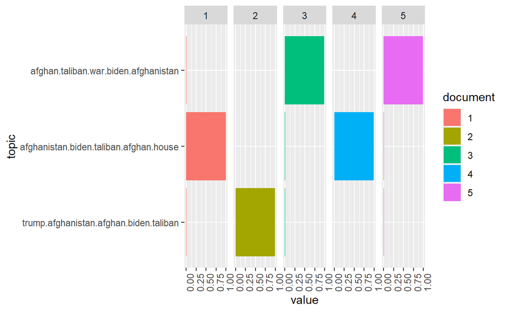

```r
# get topic proportions form example documents
topicProportionExamples2b <- theta2b[exampleIds,]
colnames(topicProportionExamples2b) <- topicNames2b
vizDataFrame2b <- melt(cbind(data.frame(topicProportionExamples2b), document = factor(1:N)), variable.name = "topic", id.vars = "document")
ggplot(data = vizDataFrame2b, aes(topic, value, fill = document), ylab = "proportion") +
  geom_bar(stat="identity") +
  theme(axis.text.x = element_text(angle = 90, hjust = 1)) +
  coord_flip() +
  facet_wrap(~ document, ncol = N)
```

### Topic Ranking

I will try to get a more meaningful order of top terms per topic by re-ranking them with a specific score (Chang et al. 2009).

The idea of re-ranking terms is similar to the idea of TF-IDF. The more a term appears in top levels w.r.t. its probability, the less meaningful it is to describe the topic. Hence, the scoring advanced favors terms to describe a topic.

```r
# re-rank top topic terms for topic names
topicNames2b <- apply(lda::top.topic.words(beta2b, 5, by.score = T), 2, paste, collapse = " ")
```

#### Approach 1

Sort topics according to their probability within the entire collection:

```r
#mean probablities over all paragraphs
topicProportions2b <- colSums(theta2b) / nDocs(DTM)
#assign the topic names we created before
names(topicProportions2b) <- topicNames2b
#show summed proportions in decreased order
sort(topicProportions2b, decreasing = TRUE)
```

```
        peace pentagon war talks taliban
                                  0.3615
trump bounties congress pentagon general
                                  0.3250
defense pullout house pakistan secretary
                                  0.3135
```

#### Approach 2

We count how often a topic appears as a primary topic within a paragraph This method is also called Rank-1.

```r
countsOfPrimaryTopics2b <- rep(0, K2)
names(countsOfPrimaryTopics2b) <- topicNames2b
for (i in 1:nDocs(DTM)) {
  topicsPerDoc2b <- theta2b[i, ] # select topic distribution for document i
  # get first element position from ordered list
  primaryTopic2b <- order(topicsPerDoc2b, decreasing = TRUE)[1]
  countsOfPrimaryTopics2b[primaryTopic2b] <- countsOfPrimaryTopics2b[primaryTopic2b] + 1
}
sort(countsOfPrimaryTopics2b, decreasing = TRUE)
```

```
        peace pentagon war talks taliban
                                     675
trump bounties congress pentagon general
                                     610
defense pullout house pakistan secretary
                                     587
```

Sorting topics by the Rank-1 method places topics with rather specific thematic coherences in upper ranks of the list.

### Wordcloud of Topic

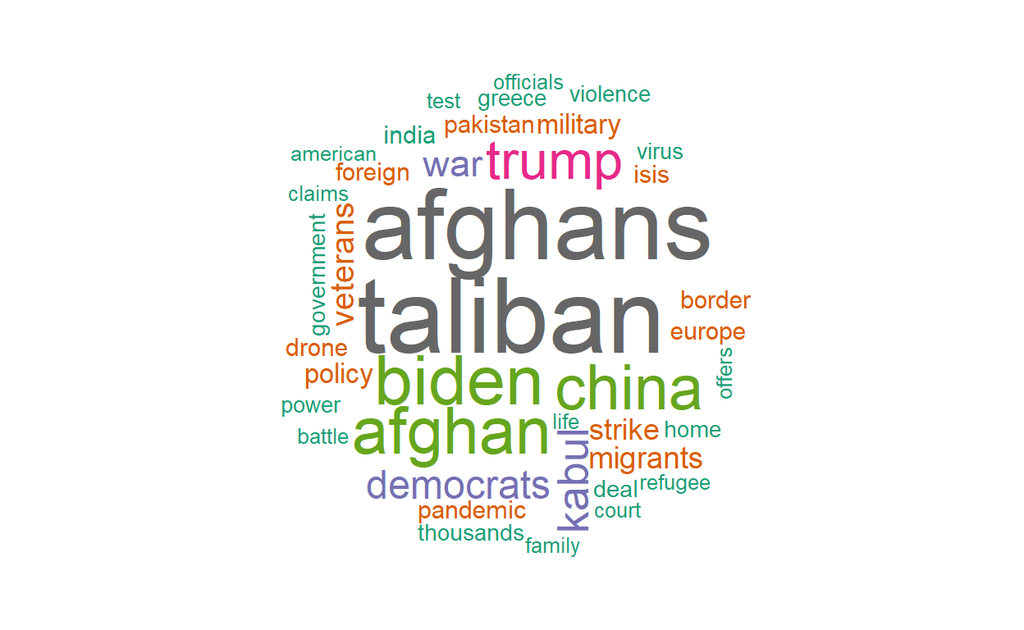

```r
#visualize topics as word cloud
topicToViz2b <- 3 # change for your own topic of interest
#topicToViz <- grep('fear', topicNames)[1] # Or select a topic by a term contained in its name
#select to 40 most probable terms from the topic by sorting the term-topic-probability vector in decreasing order
top40terms2b <- sort(tmResult2b$terms[topicToViz2b,], decreasing=TRUE)[1:40]
words2b <- names(top40terms2b)
#convert non-graph characters to combat error in wordcloud
words2b=str_replace_all(words2,"[^[:graph:]]", " ")
#extract the probabilites of each of the 40 terms
probabilities2b <- sort(tmResult2b$terms[topicToViz2b,], decreasing=TRUE)[1:40]
#visualize the terms as wordcloud
mycolors <- brewer.pal(8, "Dark2")
wordcloud(words2b, probabilities2b, random.order = FALSE, color = mycolors)
```

## Filtering Documents by “Withdrawal”

```r
topicToFilter2b <- 3  # you can set this manually ...
# ... or have it selected by a term in the topic name (e.g. 'children')
#topicToFilter2b <- grep('withdrawal', topicNames2)[1]
topicThreshold2b <- 0.2
selectedDocumentIndexes2b <- which(theta2b[, topicToFilter2b] >= topicThreshold2b)
filteredCorpus2b <- corpus[selectedDocumentIndexes2b]
# show length of filtered corpus
filteredCorpus2b
```

```
<<SimpleCorpus>>
Metadata:  corpus specific: 1, document level (indexed): 2
Content:  documents: 718
```

### Visualizing Topic Proportions Over Time

In a last step, we provide a distant view on the topics in the data over time. For this, we aggregate mean topic proportions per month for all of the topics. These aggregated topic proportions can then be visualized, e.g. as a bar plot.

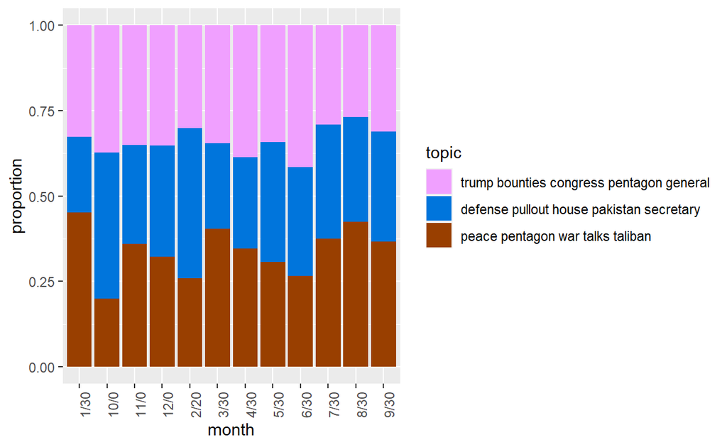

```r
#convert non-graph characters to combat error in grid.Call
topicNames2b=str_replace_all(topicNames2b,"[^[:graph:]]", " ")
# append month information for aggregation
textdata$month <- paste0(substr(textdata$month.ended, 0, 3), "0")
# get mean topic proportions per month
topic_proportion_per_month2b <- aggregate(theta2b, by = list(month = textdata$month), mean)
# set topic names to aggregated columns
colnames(topic_proportion_per_month2b)[2:(K2+1)] <- topicNames2b
# reshape data frame
vizDataFrame2b <- melt(topic_proportion_per_month2b, id.vars = "month")
# plot topic proportions per month as bar plot
ggplot(vizDataFrame2b, aes(x=month, y=value, fill=variable)) +
  geom_bar(stat = "identity") + ylab("proportion") +
  scale_fill_manual(values = paste0(alphabet(20), "FF"), name = "topic") +
  theme(axis.text.x = element_text(angle = 90, hjust = 1))
```

Unfortunately, the month variable in my data is giving me a lot of trouble visualizing in chronological order.

## Visualizing Topic Proportions By Article (Dated)

Since the date column is being difficult, I will try this visualization by article number (doc_id), since the numbers have been generated by date published before being grouped by month.

### Gibbs Method

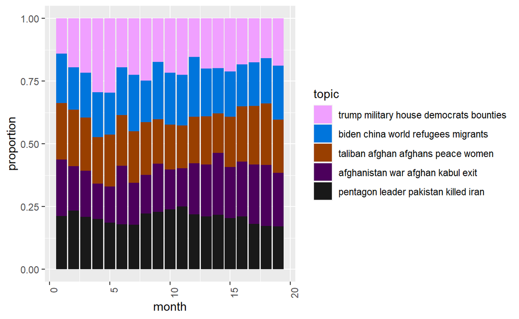

```r
textdatacleaned <- read.csv("textdatacleaned.csv")

#convert non-graph characters to combat error in grid.Call
#topicNames2b=str_replace_all(topicNames2b,"[^[:graph:]]", " ")
# append month information for aggregation
#textdata$month <- paste0(substr(textdata$month.ended, 0, 3), "0")
# get mean topic proportions per month
topic_proportion_per_month <- aggregate(theta, by = list(month = textdatacleaned$month), mean)
# set topic names to aggregated columns
colnames(topic_proportion_per_month)[2:(K+1)] <- topicNames
# reshape data frame
vizDataFrame <- melt(topic_proportion_per_month, id.vars = "month")
# plot topic proportions per month as bar plot
ggplot(vizDataFrame, aes(x=month, y=value, fill=variable)) +
  geom_bar(stat = "identity") + ylab("proportion") +
  scale_fill_manual(values = paste0(alphabet(20), "FF"), name = "topic") +
  theme(axis.text.x = element_text(angle = 90, hjust = 1))
```

### VEM Method

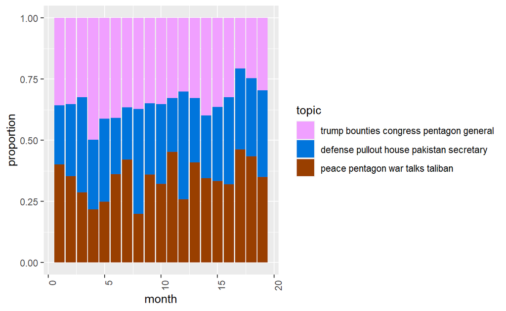

```r
textdatacleaned <- read.csv("textdatacleaned.csv")

#convert non-graph characters to combat error in grid.Call
#topicNames2b=str_replace_all(topicNames2b,"[^[:graph:]]", " ")
# append month information for aggregation
#textdata$month <- paste0(substr(textdata$month.ended, 0, 3), "0")
# get mean topic proportions per month
topic_proportion_per_month2b <- aggregate(theta2b, by = list(month = textdatacleaned$month), mean)
# set topic names to aggregated columns
colnames(topic_proportion_per_month2b)[2:(K2+1)] <- topicNames2b
# reshape data frame
vizDataFrame2b <- melt(topic_proportion_per_month2b, id.vars = "month")
# plot topic proportions per month as bar plot
ggplot(vizDataFrame2b, aes(x=month, y=value, fill=variable)) +
  geom_bar(stat = "identity") + ylab("proportion") +
  scale_fill_manual(values = paste0(alphabet(20), "FF"), name = "topic") +
  theme(axis.text.x = element_text(angle = 90, hjust = 1))
```

That gives us a much better idea of how the topics changed over the course of the 19 months being analyzed!